# Lab 10 Space and Time

Griffin Shelor

11/9/2023

The file NOAA_df_1990.csv contains data on the max temperature taken at weather stations over a 4 year period

Question 1. a) Read in the data. b) Create a new column in the dataset combining the time elements as a POSIXct data class. c) What is the Min and Max date/time that were recorded in this data set?

```r
setwd("/Users/griffinshelor/Documents/Schoolwork/UNR/GEOG616/Labs/Lab10")
NOAA_df <- read.csv("NOAA_df_1990.csv")
NOAA_df$date_posix <- as.POSIXct(NOAA_df$date, format = "%Y-%m-%d")
head(NOAA_df)
```

```
##   X julian year month day   id  z proc   lat       lon       date date_posix
## 1 1 726834 1990     1   1 3804 35 Tmax 39.35 -81.43333 1990-01-01 1990-01-01
## 2 2 726835 1990     1   2 3804 42 Tmax 39.35 -81.43333 1990-01-02 1990-01-02
## 3 3 726836 1990     1   3 3804 49 Tmax 39.35 -81.43333 1990-01-03 1990-01-03
## 4 4 726837 1990     1   4 3804 59 Tmax 39.35 -81.43333 1990-01-04 1990-01-04
## 5 5 726838 1990     1   5 3804 41 Tmax 39.35 -81.43333 1990-01-05 1990-01-05
## 6 6 726839 1990     1   6 3804 45 Tmax 39.35 -81.43333 1990-01-06 1990-01-06
```

```r
min(NOAA_df$date_posix)
```

```
## [1] "1990-01-01 PST"
```

```r
max(NOAA_df$date_posix)
```

```
## [1] "1993-12-31 PST"
```

```r
## The min date is 1990-01-01 and the max date is 1993-12-31.
```

Question 2. 1) Create a spacetime dataframe from your object for the month of July in 1992 and 2) Show the structure and 3) plot the time series and 4) spatial slot.

```r
NOAA_df_july <- NOAA_df |>
  filter(month == 7 & year == 1992)
NOAA_stdf_july <- stConstruct(NOAA_df_july, space = c(9, 10), time = 'date_posix')
str(NOAA_stdf_july)
```

```
## Formal class 'STIDF' [package "spacetime"] with 4 slots
##   ..@ data   :'data.frame':  15376 obs. of  9 variables:
##   .. ..$ X     : int [1:15376] 913 2374 3835 5280 6741 8202 9663 11124 12585 14046 ...
##   .. ..$ julian: int [1:15376] 727746 727746 727746 727746 727746 727746 727746 727746 727746 727746 ...
##   .. ..$ year  : int [1:15376] 1992 1992 1992 1992 1992 1992 1992 1992 1992 1992 ...
##   .. ..$ month : int [1:15376] 7 7 7 7 7 7 7 7 7 7 ...
##   .. ..$ day   : int [1:15376] 1 1 1 1 1 1 1 1 1 1 ...
##   .. ..$ id    : int [1:15376] 3804 3810 3811 3812 3813 3816 3820 3822 3841 3847 ...
##   .. ..$ z     : num [1:15376] 85 85 88 78 91 88 92 91 79 78 ...
##   .. ..$ proc  : chr [1:15376] "Tmax" "Tmax" "Tmax" "Tmax" ...
##   .. ..$ date  : chr [1:15376] "1992-07-01" "1992-07-01" "1992-07-01" "1992-07-01" ...
##   ..@ sp     :Formal class 'SpatialPoints' [package "sp"] with 3 slots
##   .. .. ..@ coords     : num [1:15376, 1:2] 39.3 35.7 35.6 35.4 32.7 ...
##   .. .. .. ..- attr(*, "dimnames")=List of 2
##   .. .. .. .. ..$ : NULL
##   .. .. .. .. ..$ : chr [1:2] "lat" "lon"
##   .. .. ..@ bbox       : num [1:2, 1:2] 32.1 -100 45.9 -80
##   .. .. .. ..- attr(*, "dimnames")=List of 2
##   .. .. .. .. ..$ : chr [1:2] "lat" "lon"
##   .. .. .. .. ..$ : chr [1:2] "min" "max"
##   .. .. ..@ proj4string:Formal class 'CRS' [package "sp"] with 1 slot
##   .. .. .. .. ..@ projargs: chr NA
##   ..@ time   :An xts object on 1992-07-01 / 1992-07-31 containing:
##   Data:    integer [15376, 1]
##   Columns: timeIndex
##   Index:   POSIXct,POSIXt [15376] (TZ: "")
##   ..@ endTime: POSIXct[1:15376], format: "1992-07-01" "1992-07-01" ...
```

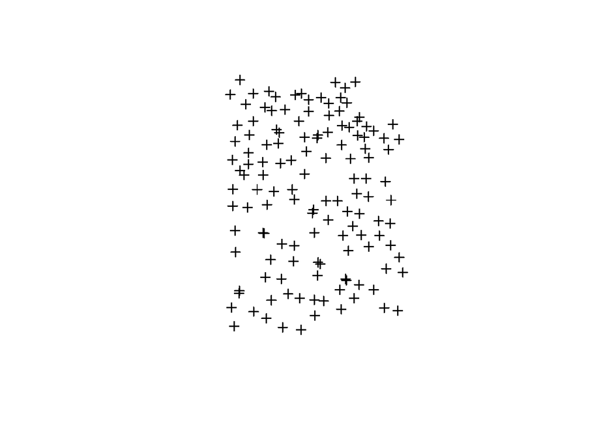

```r
plot(NOAA_stdf_july@sp)
```

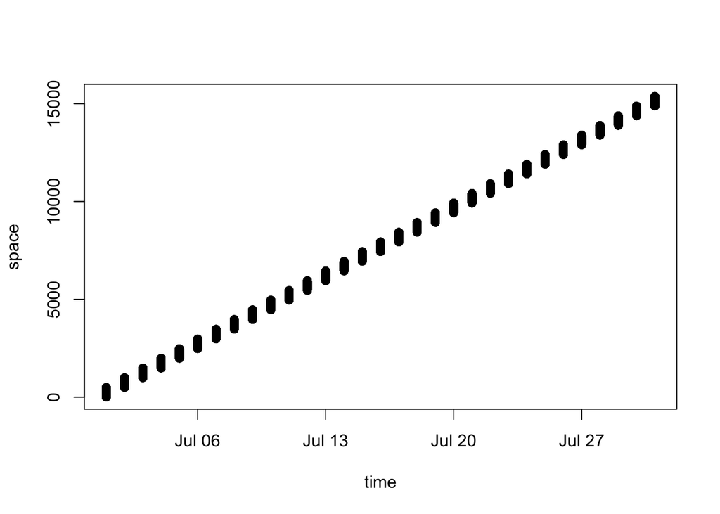

```r
plot(NOAA_stdf_july)
```

Question 3. The data contain several measurements (z) and the type of measurement is given in the proc column. 1) Subset your data to only the Tmax data. 2) Plot your data in 4 time intervals, with the Tmax variable shown in 5 increments. What are the min and max Tmax values?

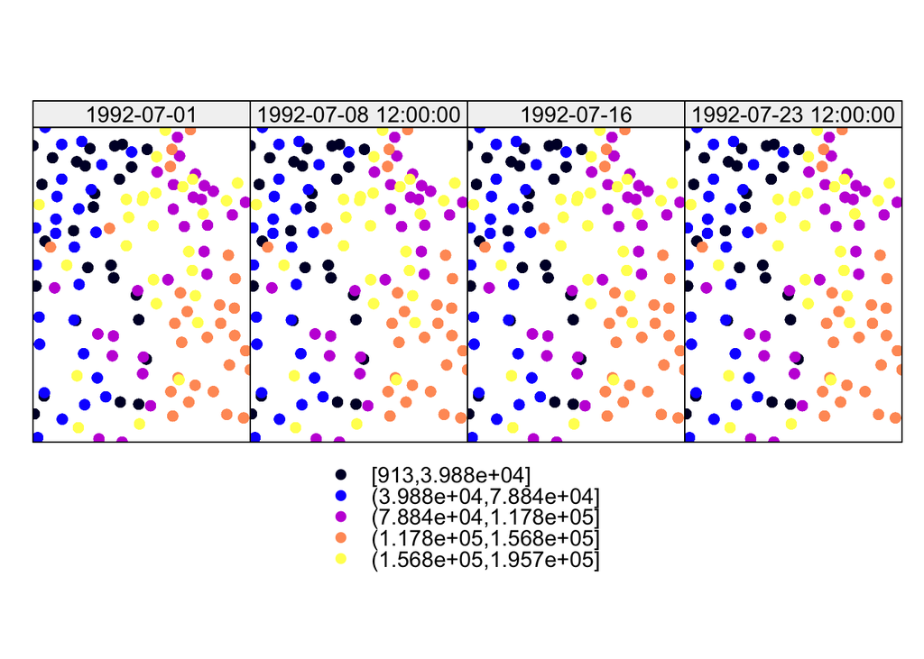

```r
NOAA_df_julytmax <- NOAA_df_july |>
  filter(proc == "Tmax")
NOAA_stdf_julytmax <- stConstruct(NOAA_df_julytmax, space = c(9, 10), time = 'date_posix')
stplot(NOAA_stdf_julytmax, number = 4, cuts = 5)
```

```r
summary(NOAA_stdf_julytmax)
```

```
## Object of class STIDF
##  with Dimensions (s, t, attr): (4123, 4123, 9)
## [[Spatial:]]
## Object of class SpatialPoints
## Coordinates:
##           min       max
## lat  32.13334  45.86666
## lon -99.96667 -80.03333
## Is projected: NA
## proj4string : [NA]
## Number of points: 4123
## [[Temporal:]]
##      Index              timeIndex
##  Min.   :1992-07-01   Min.   :   1
##  1st Qu.:1992-07-08   1st Qu.:1032
##  Median :1992-07-16   Median :2062
##  Mean   :1992-07-16   Mean   :2062
##  3rd Qu.:1992-07-24   3rd Qu.:3092
##  Max.   :1992-07-31   Max.   :4123
## [[Data attributes:]]
##        X              julian            year          month        day
##  Min.   :   913   Min.   :727746   Min.   :1992   Min.   :7   Min.   : 1
##  1st Qu.: 49838   1st Qu.:727753   1st Qu.:1992   1st Qu.:7   1st Qu.: 8
##  Median : 97894   Median :727761   Median :1992   Median :7   Median :16
##  Mean   : 98052   Mean   :727761   Mean   :1992   Mean   :7   Mean   :16
##  3rd Qu.:146062   3rd Qu.:727769   3rd Qu.:1992   3rd Qu.:7   3rd Qu.:24
##  Max.   :195735   Max.   :727776   Max.   :1992   Max.   :7   Max.   :31
##        id              z              proc               date
##  Min.   : 3804   Min.   : 57.00   Length:4123        Length:4123
##  1st Qu.:13877   1st Qu.: 79.00   Class :character   Class :character
##  Median :14825   Median : 85.00   Mode  :character   Mode  :character
##  Mean   :29104   Mean   : 84.02
##  3rd Qu.:14943   3rd Qu.: 91.00
##  Max.   :94918   Max.   :102.00
```

```r
## The min and max Tmax values are 57 and 102.
```

Question 4. What is the average of maximum temperature for the last week in July?

```r
NOAA_df_julytmax_lastweek <- NOAA_df_julytmax |>
  filter(day > 23)
mean(NOAA_df_julytmax_lastweek$z)
```

```
## [1] 83.53853
```

```r
## The average of max temps for the last week in July is 83.53853.
```

Question 5 - a) Construct a time series object of the dew point temperature data (TDP) for the entire month of July of 1992. b) use the Auto and Cross Covariance function (acf) to estimate the correlation associated with time lag in days in which the data are autocorrelated.

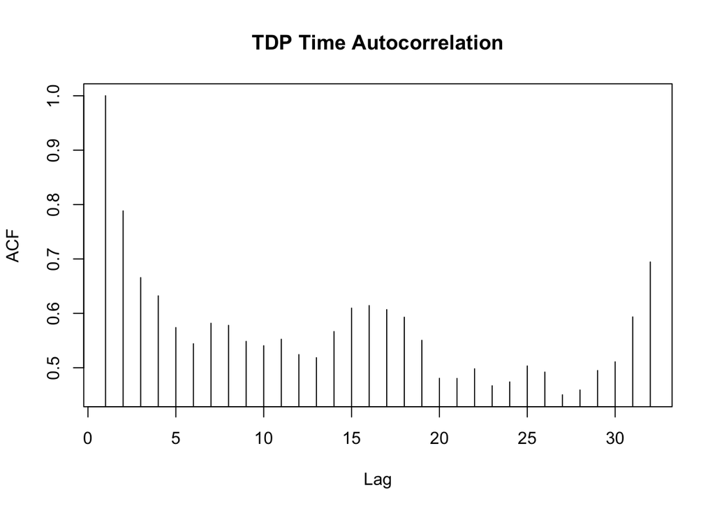

```r
NOAA_df_julyTDP <- NOAA_df_july |>
  filter(proc == "TDP") |>
  select(date_posix, z)
julyTDP_ts <- ts(NOAA_df_julyTDP)
julyTDP_ts_acf <- acf(julyTDP_ts, plot = F)

plot(julyTDP_ts_acf$acf[,2,2], xlab = 'Lag', ylab = 'ACF', main = 'TDP Time Autocorrelation', type='h')
```

## Question 6 Graduate students - XC for undergrads

Using the time series object of the dew point temperature data (TDP) for the entire month of July of 1992 that you created in Question 5. A) Create a space-time variogram, B) fit the nugget range and sill for the space and time components. C) create a prediction grid of a 20x20 lat long size, and dates using the code here

” as.POSIXct(as.Date(“1993-07-01”) + seq(3, 28, length = 6), tz=‘PDT’) ”

Krige and plot your result

```r
set.seed(802)
NOAA_df_julyTDP <- NOAA_df_july |>
  filter(proc == "TDP")
julyTDP_stdf <- stConstruct(NOAA_df_julyTDP, space = c(9, 10), time = 12)
class(julyTDP_stdf)
```

```
## [1] "STIDF"
## attr(,"package")
## [1] "spacetime"
```

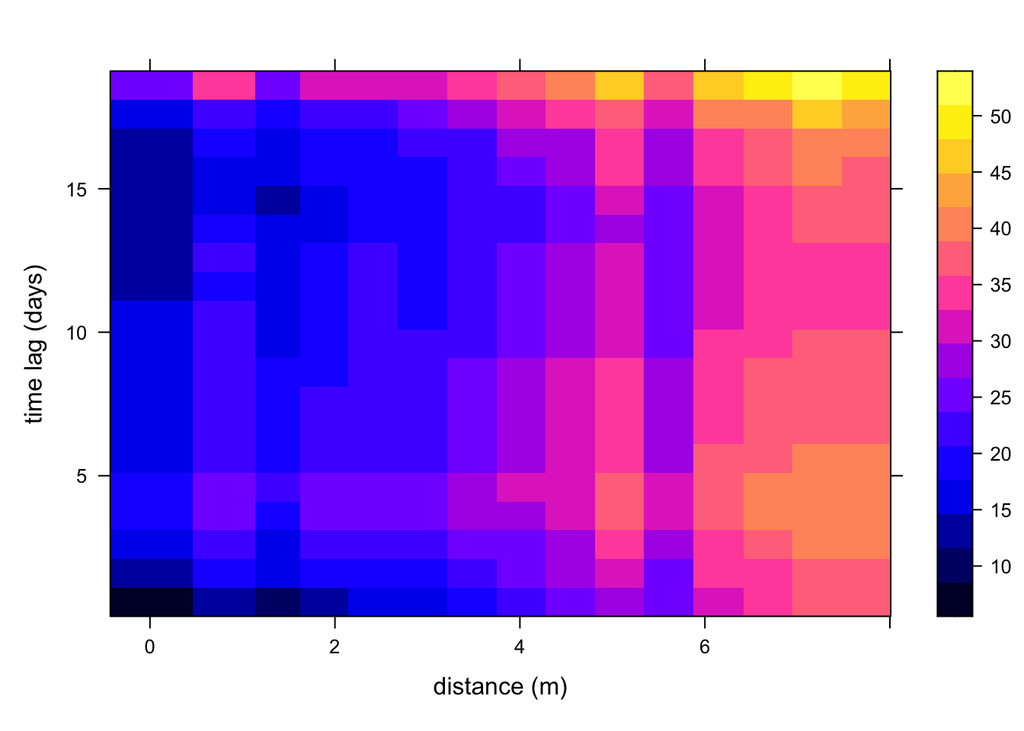

```r
julyTDP_vg <- variogram(object = z ~ 1,
                        data = julyTDP_stdf,
                        tunit = "days",
                        tlags = 0.1:20)

plot(julyTDP_vg)
```

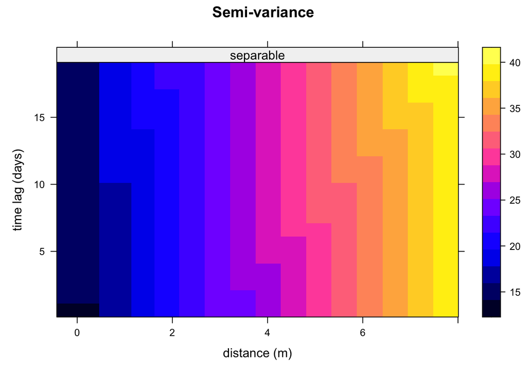

```r
sepVgm <- vgmST(stModel = "separable",
space = vgm(30, "Exp", 400, nugget = 0.1),
time = vgm(30, "Exp", 5, nugget = 0.1),
sill = 45)
sepVgm <- fit.StVariogram(julyTDP_vg, sepVgm)
plot(julyTDP_vg, sepVgm, main = "Semi-variance")
```

```r
bbox(julyTDP_stdf)
```

```
##           min       max
## lat  32.13334  45.58333
## lon -99.96667 -80.03333
```

```r
spat_pred_grid <- expand.grid(
lon = seq(-100, -80, length = 20),
lat = seq(32, 46, length = 20)) |>
SpatialPoints(proj4string = CRS(proj4string(julyTDP_stdf)))
class(spat_pred_grid)
```

```
## [1] "SpatialPoints"
## attr(,"package")
## [1] "sp"
```

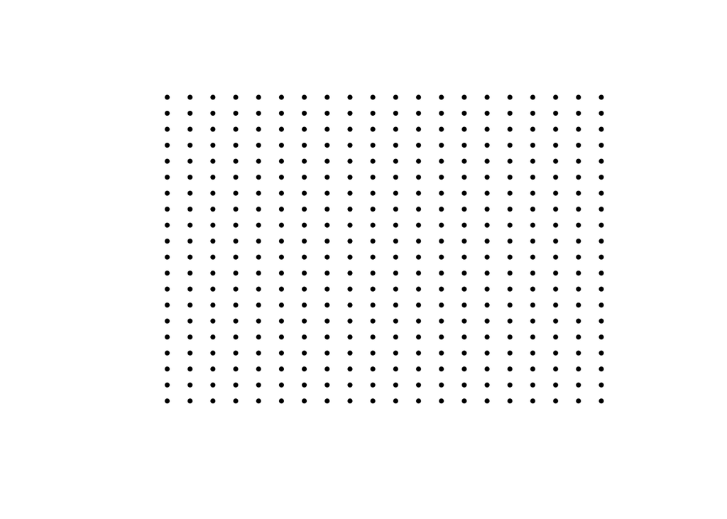

```r
plot(spat_pred_grid, pch=19, cex = 0.5)
```

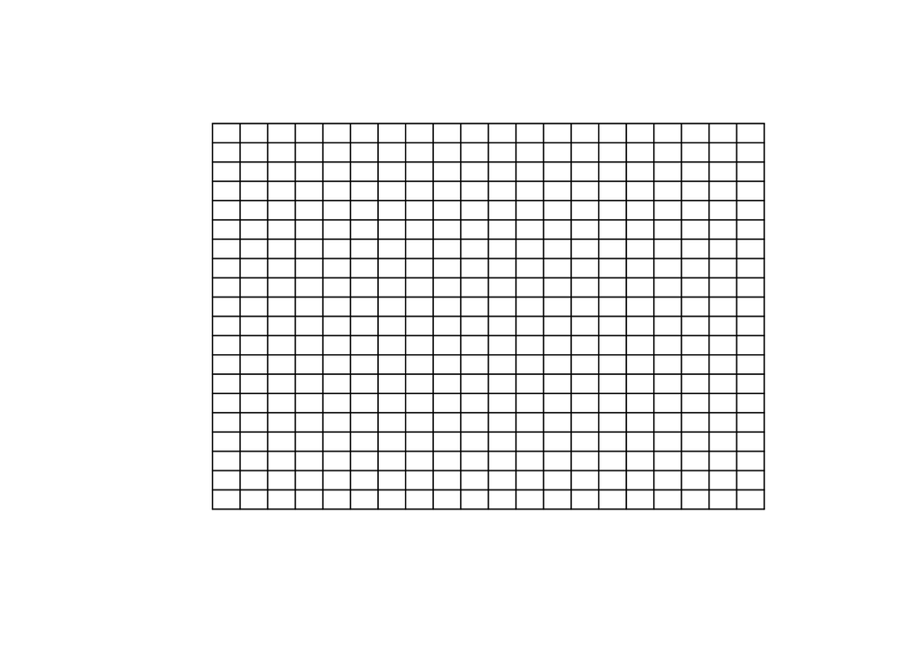

```r
gridded(spat_pred_grid) <- TRUE
plot(spat_pred_grid)
```

```r
temp_pred_grid <- as.POSIXct(as.Date("1993-07-01") + seq(3, 28, length = 6), tz="PDT")
temp_pred_grid
```

```
## [1] "1993-07-04 GMT" "1993-07-09 GMT" "1993-07-14 GMT" "1993-07-19 GMT"
## [5] "1993-07-24 GMT" "1993-07-29 GMT"
```

```r
DE_pred <- STF(sp = spat_pred_grid,# spatial part
time = temp_pred_grid)# temporal part
class(DE_pred)
```

```
## [1] "STF"
## attr(,"package")
## [1] "spacetime"
```

```r
summary(DE_pred)
```

```
## Object of class STF
##  with Dimensions (s, t, attr): (400, 6)
## [[Spatial:]]
## Object of class SpatialPixels
## Coordinates:
##            min       max
## lon -100.52632 -79.47368
## lat   31.63158  46.36842
## Is projected: NA
## proj4string : [NA]
## Number of points: 400
## Grid attributes:
##     cellcentre.offset  cellsize cells.dim
## lon              -100 1.0526316        20
## lat                32 0.7368421        20
## [[Temporal:]]
##      Index                       timeIndex
##  Min.   :1993-07-04 00:00:00   Min.   :1.00
##  1st Qu.:1993-07-10 06:00:00   1st Qu.:2.25
##  Median :1993-07-16 12:00:00   Median :3.50
##  Mean   :1993-07-16 12:00:00   Mean   :3.50
##  3rd Qu.:1993-07-22 18:00:00   3rd Qu.:4.75
##  Max.   :1993-07-29 00:00:00   Max.   :6.00
```

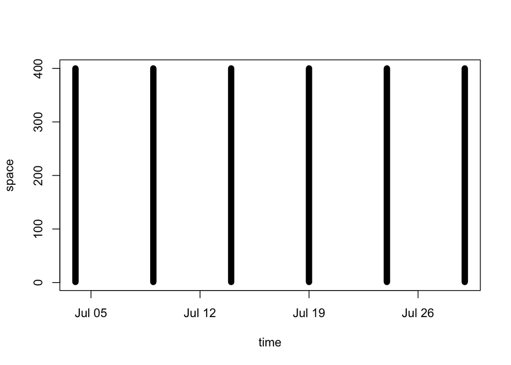

```r
plot(DE_pred)
```

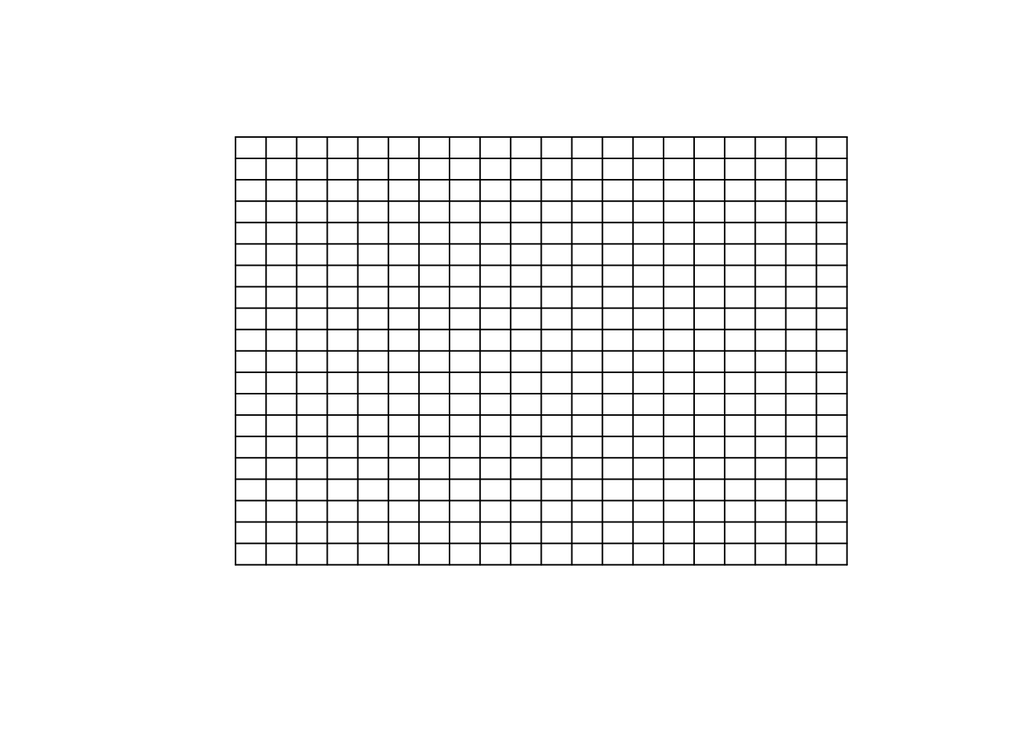

```r
plot(DE_pred@sp)
```

```r
# julyTDP_stdf_v2 <- as(julyTDP_stdf[, -14], "STIDF")# convert to STIDF - omitting one problematic column
# julyTDP_stdf_v2 <- subset(julyTDP_stdf_v2, !is.na(julyTDP_stdf_v2$z))

pred_kriged <- krigeST(z ~ 1,
data = julyTDP_stdf,
newdata = DE_pred,
modelList = sepVgm,
computeVar = TRUE)
```

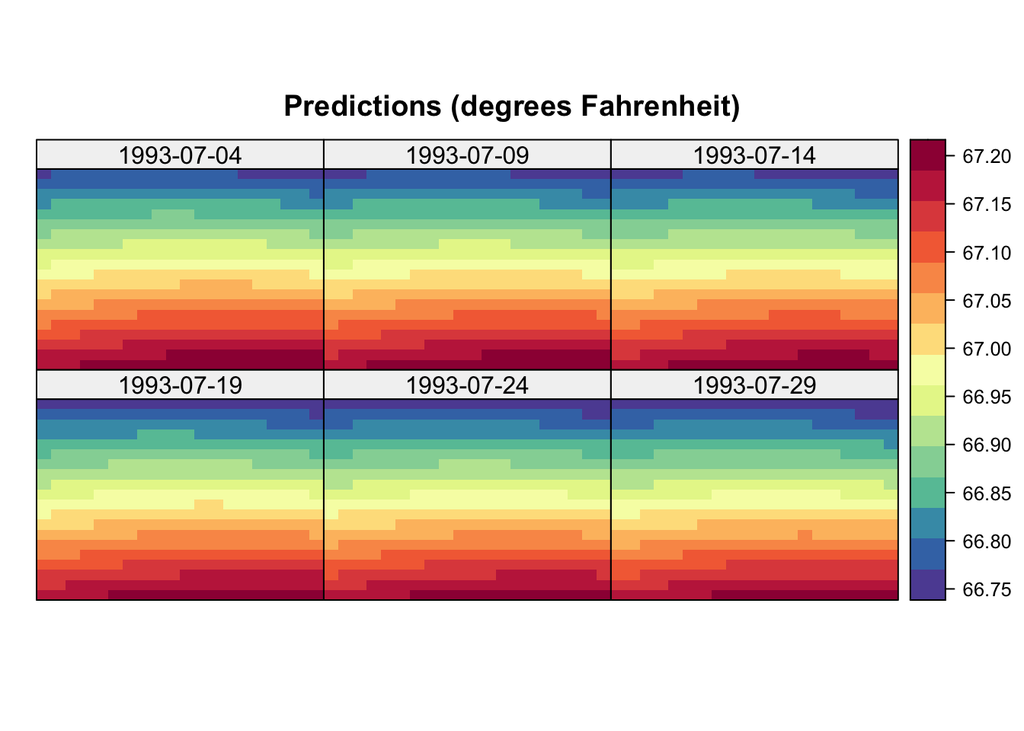

```r
color_pal <- rev(colorRampPalette(brewer.pal(11, "Spectral"))(16))
stplot(pred_kriged,
main = "Predictions (degrees Fahrenheit)",
layout = c(3, 2),
col.regions = color_pal)
```